# Red Wine Quality Exploration

Eric

October 24, 2017

# Red Wine Quality Exploration by Eric

“Tasty like a fine wine” - ever hear this expression before? Ever wonder what makes wine, a fermented grape juice by nature, taste better with age? Does all wine taste better with age? While the age of wine is interesting in measuring the quality of it, this data exploration project will dive into the chemical properties of red wine and explore what makes a good red wine better than others.

# Univariate Plots Section

## About the Data

This report explores over 1500 observations containing information about 12 different attributes of the wine.

```
##  [1] "X"                    "fixed.acidity"        "volatile.acidity"
##  [4] "citric.acid"          "residual.sugar"       "chlorides"
##  [7] "free.sulfur.dioxide"  "total.sulfur.dioxide" "density"
## [10] "pH"                   "sulphates"            "alcohol"
## [13] "quality"              "quality_rank"
```

```
##        X          fixed.acidity   volatile.acidity  citric.acid
##  Min.   :   1.0   Min.   : 4.60   Min.   :0.1200   Min.   :0.000
##  1st Qu.: 400.5   1st Qu.: 7.10   1st Qu.:0.3900   1st Qu.:0.090
##  Median : 800.0   Median : 7.90   Median :0.5200   Median :0.260
##  Mean   : 800.0   Mean   : 8.32   Mean   :0.5278   Mean   :0.271
##  3rd Qu.:1199.5   3rd Qu.: 9.20   3rd Qu.:0.6400   3rd Qu.:0.420
##  Max.   :1599.0   Max.   :15.90   Max.   :1.5800   Max.   :1.000
##  residual.sugar     chlorides       free.sulfur.dioxide
##  Min.   : 0.900   Min.   :0.01200   Min.   : 1.00
##  1st Qu.: 1.900   1st Qu.:0.07000   1st Qu.: 7.00
##  Median : 2.200   Median :0.07900   Median :14.00
##  Mean   : 2.539   Mean   :0.08747   Mean   :15.87
##  3rd Qu.: 2.600   3rd Qu.:0.09000   3rd Qu.:21.00
##  Max.   :15.500   Max.   :0.61100   Max.   :72.00
##  total.sulfur.dioxide    density             pH          sulphates
##  Min.   :  6.00       Min.   :0.9901   Min.   :2.740   Min.   :0.3300
##  1st Qu.: 22.00       1st Qu.:0.9956   1st Qu.:3.210   1st Qu.:0.5500
##  Median : 38.00       Median :0.9968   Median :3.310   Median :0.6200
##  Mean   : 46.47       Mean   :0.9967   Mean   :3.311   Mean   :0.6581
##  3rd Qu.: 62.00       3rd Qu.:0.9978   3rd Qu.:3.400   3rd Qu.:0.7300
##  Max.   :289.00       Max.   :1.0037   Max.   :4.010   Max.   :2.0000
##     alcohol         quality         quality_rank
##  Min.   : 8.40   Min.   :3.000   poor     :  63
##  1st Qu.: 9.50   1st Qu.:5.000   average  :1319
##  Median :10.20   Median :6.000   excellent: 217
##  Mean   :10.42   Mean   :5.636
##  3rd Qu.:11.10   3rd Qu.:6.000
##  Max.   :14.90   Max.   :8.000
```

```
## 'data.frame':    1599 obs. of  14 variables:
##  $ X                   : int  1 2 3 4 5 6 7 8 9 10 ...
##  $ fixed.acidity       : num  7.4 7.8 7.8 11.2 7.4 7.4 7.9 7.3 7.8 7.5 ...
##  $ volatile.acidity    : num  0.7 0.88 0.76 0.28 0.7 0.66 0.6 0.65 0.58 0.5 ...
##  $ citric.acid         : num  0 0 0.04 0.56 0 0 0.06 0 0.02 0.36 ...
##  $ residual.sugar      : num  1.9 2.6 2.3 1.9 1.9 1.8 1.6 1.2 2 6.1 ...
##  $ chlorides           : num  0.076 0.098 0.092 0.075 0.076 0.075 0.069 0.065 0.073 0.071 ...
##  $ free.sulfur.dioxide : num  11 25 15 17 11 13 15 15 9 17 ...
##  $ total.sulfur.dioxide: num  34 67 54 60 34 40 59 21 18 102 ...
##  $ density             : num  0.998 0.997 0.997 0.998 0.998 ...
##  $ pH                  : num  3.51 3.2 3.26 3.16 3.51 3.51 3.3 3.39 3.36 3.35 ...
##  $ sulphates           : num  0.56 0.68 0.65 0.58 0.56 0.56 0.46 0.47 0.57 0.8 ...
##  $ alcohol             : num  9.4 9.8 9.8 9.8 9.4 9.4 9.4 10 9.5 10.5 ...
##  $ quality             : int  5 5 5 6 5 5 5 7 7 5 ...
##  $ quality_rank        : Ord.factor w/ 3 levels "poor"<"average"<..: 2 2 2 2 2 2 2 3 3 2 ...
```

## Wine Quality Distribution

The minimum value of the quality of wine is a 3 and the highest scored observation received an 8 for wine quality. The median quality score equals 6 and the bulk of the quality scores fall within the [5,6] range.

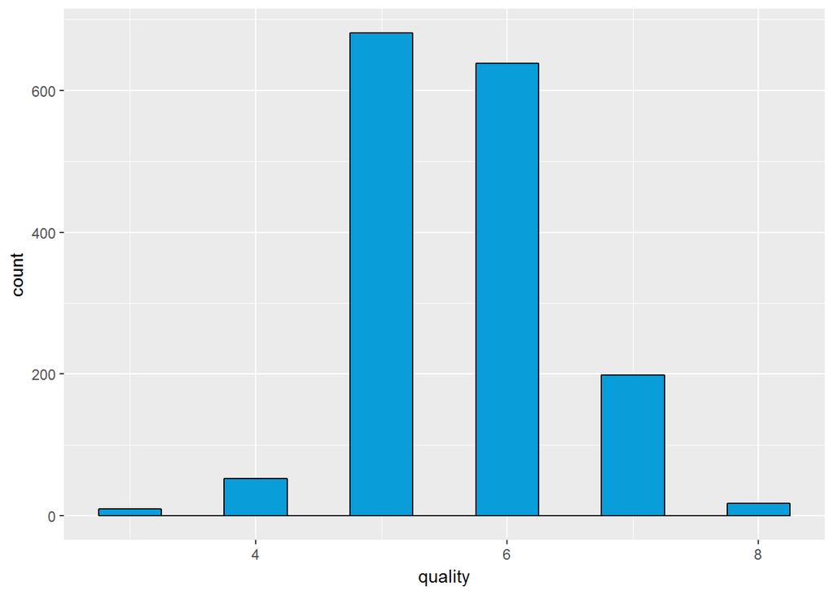

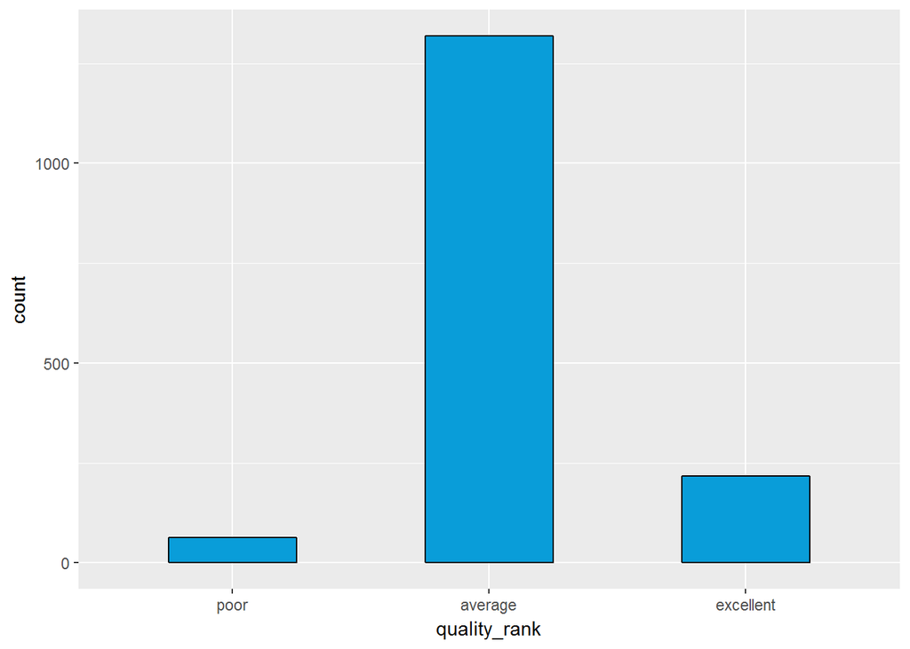

One thing that stood out in these plots of the wine quality is that the majority of the observations fall into the average wine quality bucket. This suggests the data set might not be the most trusted data as the majority of wine tasted could have been in the medium price range or did the data get collected at a specific location (ie a gas station or convenience store)? A more concrete concern with this data is how the poor and excellent wine qualities have low observation counts. These factors will have to go through some sort of normalization in order to smooth out the distributions.

## Distributions For the Remaining Attributes

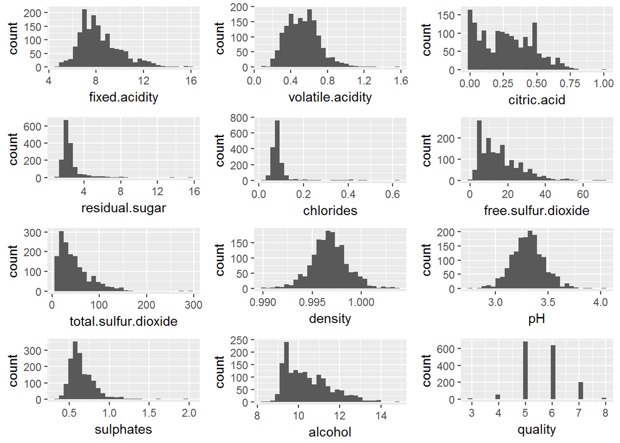

# Univariate Analysis

The univariate plots shed light to the behavior of the various chemical properties of the wine data.

## Structure of the Dataset

- The following properties are normally distributed: Volatile acidity, Density, pH
- The following properties are positively skewed: Fixed acidity, Citric acid, Free sulfur dioxide, Total sulfur dioxide, Sulphates, Alcohol
- The following properties are long-tailed skewed: Residual sugar, Chlorides

## Main Feature of Interest

Main feature of interest in the data is quality of the wine. Much of the bivariate analysis should be centered around this feature as the independent variable. This exploration will hopefully lead to an understanding of which factors contribute / how they contribute to the quality of wine.

## Unusual Distributions Investigated

For the features following a skewed or long-tailed distribution, I performed arithmetic operations on the data in order to transform them closer to a normal distribution.

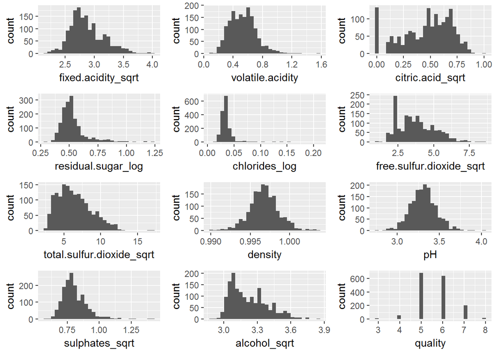

# Bivariate Plots Section

A correlation overview of the bivariate relationships can be seen below. Clearly, it appears some attributes have a greater correlation to the quality of wine than others do.

```
##                      fixed.acidity volatile.acidity citric.acid
## fixed.acidity           1.00000000     -0.256130895  0.67170343
## volatile.acidity       -0.25613089      1.000000000 -0.55249568
## citric.acid             0.67170343     -0.552495685  1.00000000
## residual.sugar          0.11477672      0.001917882  0.14357716
## chlorides               0.09370519      0.061297772  0.20382291
## free.sulfur.dioxide    -0.15379419     -0.010503827 -0.06097813
## total.sulfur.dioxide   -0.11318144      0.076470005  0.03553302
## density                 0.66804729      0.022026232  0.36494718
## pH                     -0.68297819      0.234937294 -0.54190414
## sulphates               0.18300566     -0.260986685  0.31277004
## alcohol                -0.06166827     -0.202288027  0.10990325
## quality                 0.12405165     -0.390557780  0.22637251
##                      residual.sugar    chlorides free.sulfur.dioxide
## fixed.acidity           0.114776724  0.093705186        -0.153794193
## volatile.acidity        0.001917882  0.061297772        -0.010503827
## citric.acid             0.143577162  0.203822914        -0.060978129
## residual.sugar          1.000000000  0.055609535         0.187048995
## chlorides               0.055609535  1.000000000         0.005562147
## free.sulfur.dioxide     0.187048995  0.005562147         1.000000000
## total.sulfur.dioxide    0.203027882  0.047400468         0.667666450
## density                 0.355283371  0.200632327        -0.021945831
## pH                     -0.085652422 -0.265026131         0.070377499
## sulphates               0.005527121  0.371260481         0.051657572
## alcohol                 0.042075437 -0.221140545        -0.069408354
## quality                 0.013731637 -0.128906560        -0.050656057
##                      total.sulfur.dioxide     density          pH
## fixed.acidity                 -0.11318144  0.66804729 -0.68297819
## volatile.acidity               0.07647000  0.02202623  0.23493729
## citric.acid                    0.03553302  0.36494718 -0.54190414
## residual.sugar                 0.20302788  0.35528337 -0.08565242
## chlorides                      0.04740047  0.20063233 -0.26502613
## free.sulfur.dioxide            0.66766645 -0.02194583  0.07037750
## total.sulfur.dioxide           1.00000000  0.07126948 -0.06649456
## density                        0.07126948  1.00000000 -0.34169933
## pH                            -0.06649456 -0.34169933  1.00000000
## sulphates                      0.04294684  0.14850641 -0.19664760
## alcohol                       -0.20565394 -0.49617977  0.20563251
## quality                       -0.18510029 -0.17491923 -0.05773139
##                         sulphates     alcohol     quality
## fixed.acidity         0.183005664 -0.06166827  0.12405165
## volatile.acidity     -0.260986685 -0.20228803 -0.39055778
## citric.acid           0.312770044  0.10990325  0.22637251
## residual.sugar        0.005527121  0.04207544  0.01373164
## chlorides             0.371260481 -0.22114054 -0.12890656
## free.sulfur.dioxide   0.051657572 -0.06940835 -0.05065606
## total.sulfur.dioxide  0.042946836 -0.20565394 -0.18510029
## density               0.148506412 -0.49617977 -0.17491923
## pH                   -0.196647602  0.20563251 -0.05773139
## sulphates             1.000000000  0.09359475  0.25139708
## alcohol               0.093594750  1.00000000  0.47616632
## quality               0.251397079  0.47616632  1.00000000
```

The correlation matrix gives a preview into what the bivariate scatterplots look like between quality and the other features.

## Top Correlated Features (To Quality)

I ran Pearson’s correlation tests between the wine quality against the remaining wine properties and found 4 features with a correlation coefficient of at least 0.2 with the wine quality:

- Alcohol, r = 0.476
- Volatile.acidity, r = -0.391
- Sulphates, r = 0.251
- Citric.acid, r = 0.226

## Bivariate Box Plots - A Bivariate Quality Investigation

Building off of the correlation calculated, box plots were created below to observe anythingelse that may have not been captured between the bivariate correlation table.

Beginning with the supporting features to the quality feature, that is, the main feature of interest, I’m going to explore acidity (fixed, volatile, citric) and pH since they could have a big impact on the quality of the wine. It’s important to understand too acidic of wine can give off a strong vinegar taste. Also, wine with a pH outside the range of 3-4 could be too basic or too acidic and affect the taste.

The plots for the attributes of acidity and pH are below,

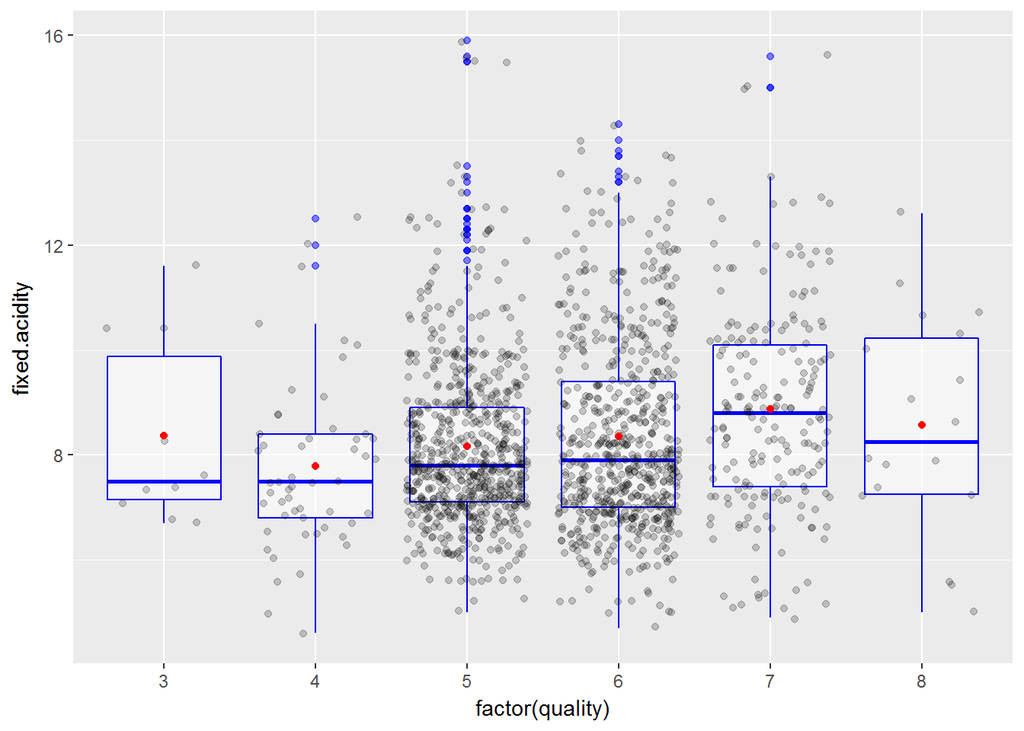

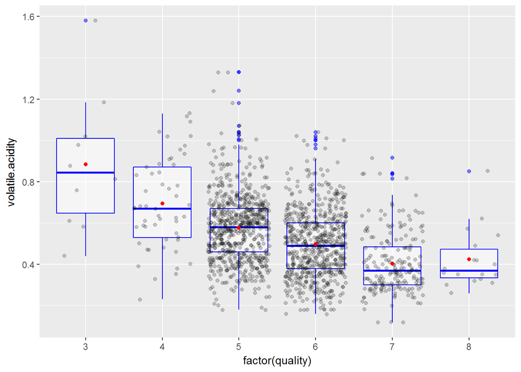

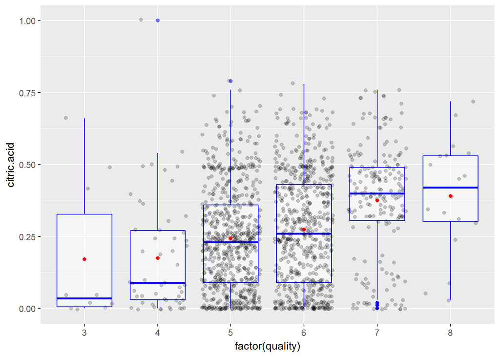

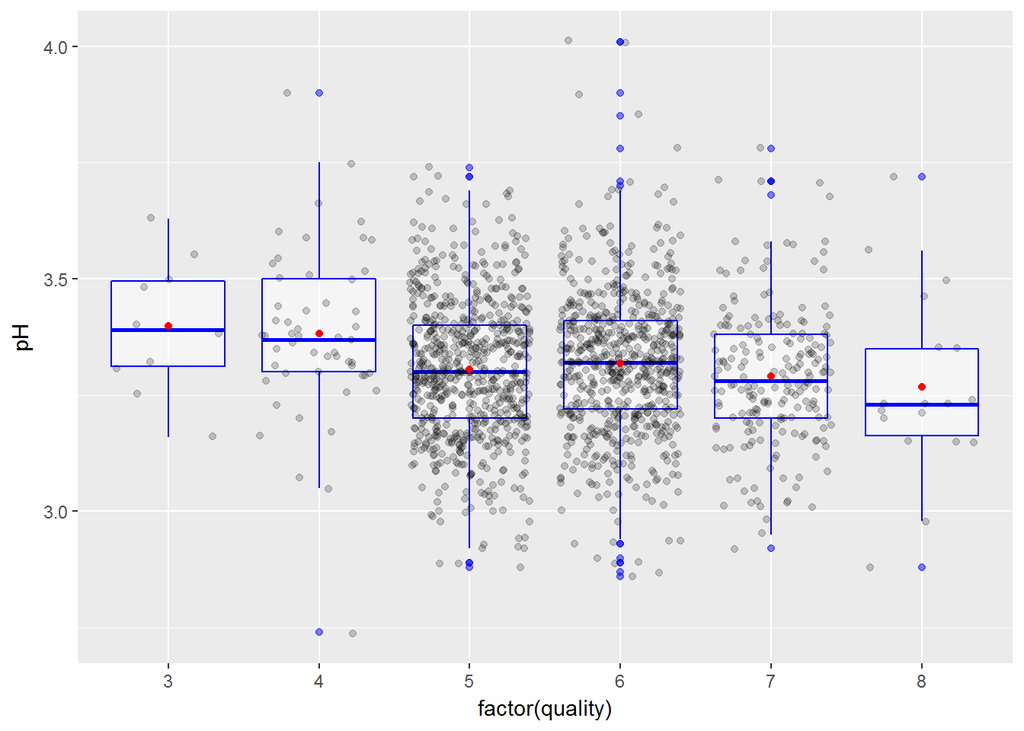

- Fixed.acidity - As fixed acidity increases or decreases, there’s little effect to the quality. The mean values of fixed acidity don’t fluctuate much as quality increases.
- Volatile.acidity - As volatile acidity increases, the quality of wine decreases, so there’s an inverse relationship between the two.
- Citric.acid - As citric acid increases, there’s a slight uptick in wine quality.
- pH - As pH decreases (also, becomes more acidic), the quality of wine slightly increases as well.

I wanted to explore how the different types of acid affected the pH. Plots comparing to the3 types of acid are below.

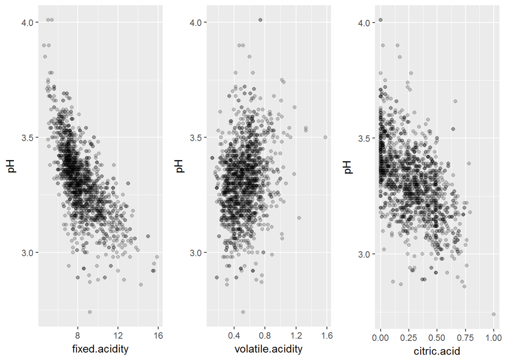

Putting these 3 plots on the same grid made it easier to see how for volatile acid the negative correlation that exists between pH and acid doesn’t hold true here.

Plotted below are the remaining attributes compared to wine quality.

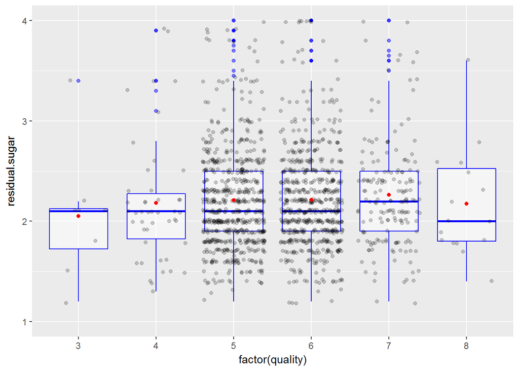

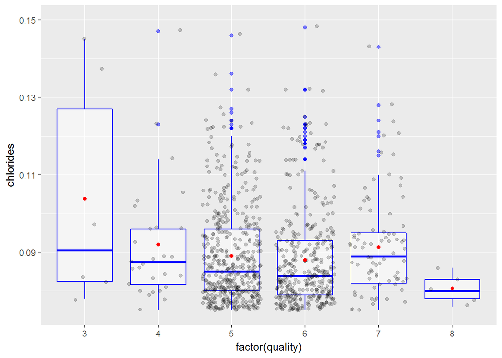

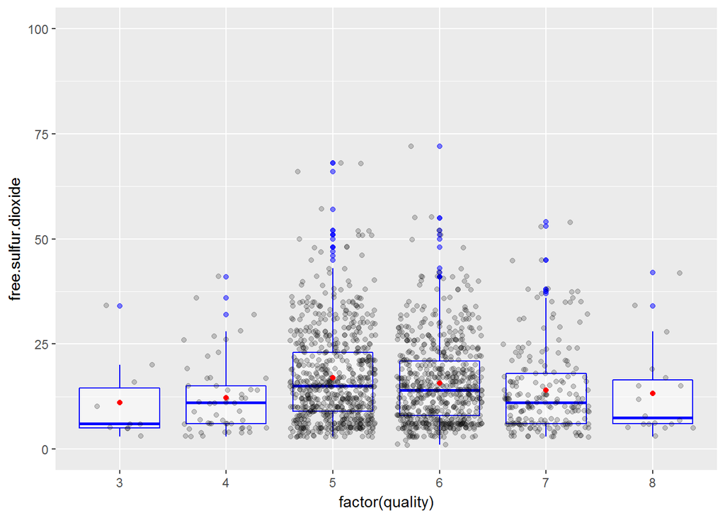

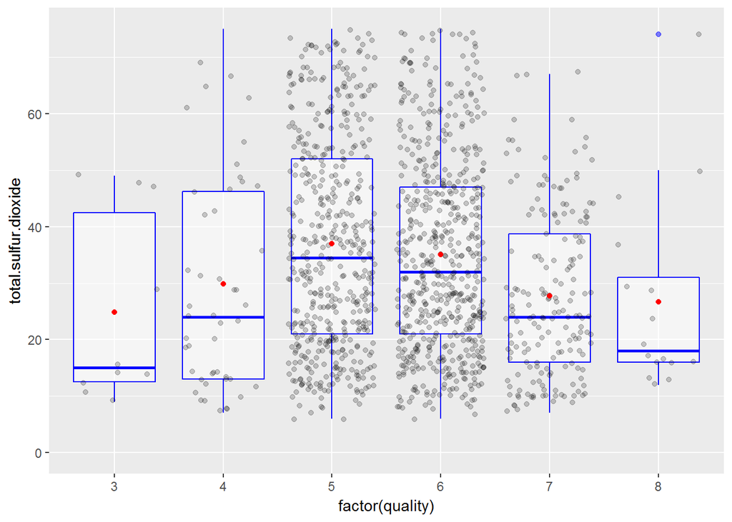

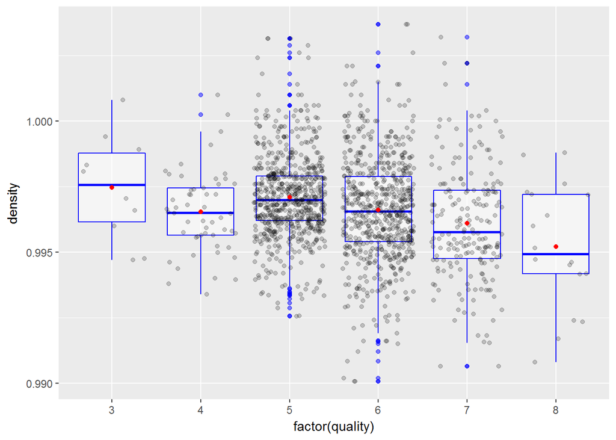

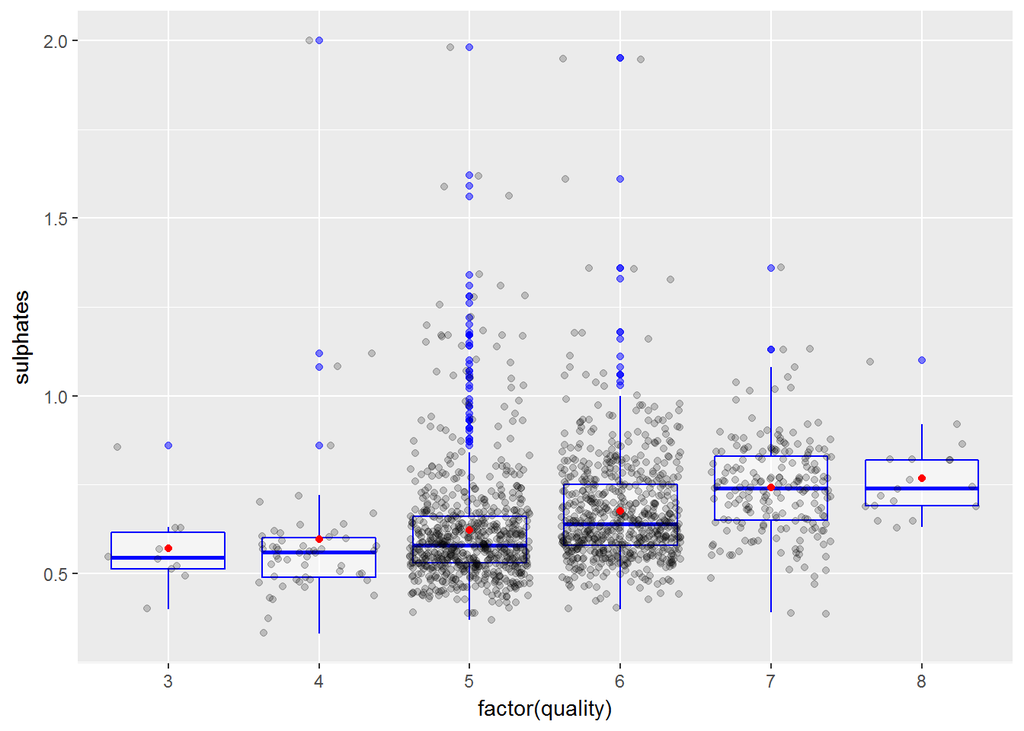

- Residual.sugar - Residual sugar content in wine doesn’t seem to have any affect on the quality as the mean levels stay relatively equal for varying quality of wine.
- Chlorides - As chlorides decrease, there’s a very minor increase in the quality.
- Free.sulfur.dioxide - For free sulfur dioxide, it would appear that absolutely low levels on dioxide results in absolutely low levels of quality wine. While, absolutely high levels of dioxide results in average quality (~ 4.5 - 6.5).
- Total.sulfur.dioxide - This attribute takes on a similar patter as free sulfur dioxide.
- Density - As density decreases, the quality of wine has a slight increase.
- Sulphates - As sulphates increase, the quality of wine increases as well.

Since quality and alcohol held the strongest correlation coefficient of over 0.4 I decided to perform a deeper investigation of the attribute by also taking a look at how the quality_rank attribute performed with varying levels of alcohol.

## Bivariate Plots - Quality vs Alcohol

The box plot of quality vs alcohol demonstrates the strong correlation coefficient between the two attributes.

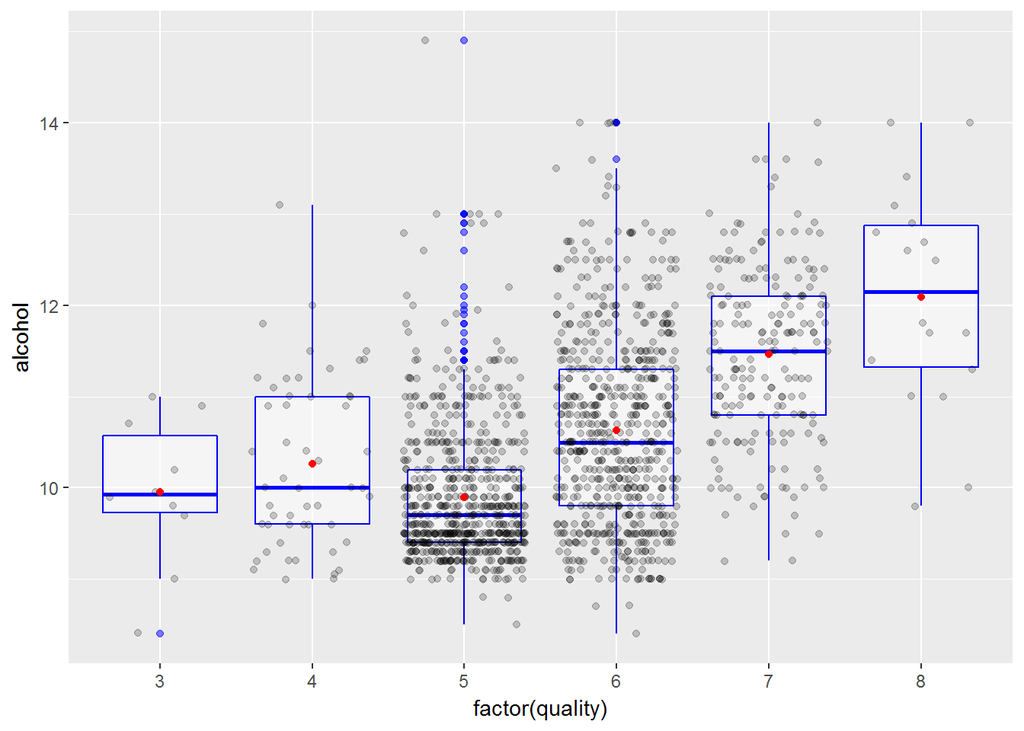

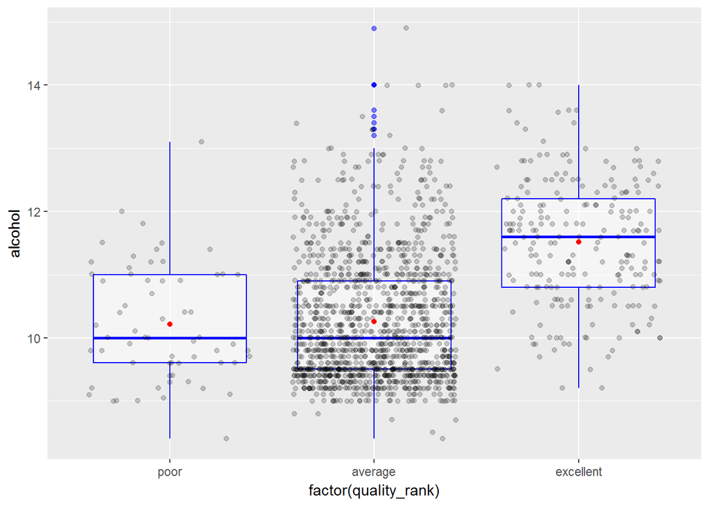

A puzzling aspect is how there still exists a handful of outliers in the box plot. This suggests alcohol isn’t the only attribute with a contribution to the quality of wine. The bivariate correlation of quality supports this idea. A linear model was calculated below to gain insight into just how much other attributes and alcohol affect the quality of wine.

```
##
## Call:
## lm(formula = as.numeric(quality) ~ alcohol, data = wine_df)
##
## Residuals:
##     Min      1Q  Median      3Q     Max
## -2.8442 -0.4112 -0.1690  0.5166  2.5888
##
## Coefficients:
##             Estimate Std. Error t value Pr(>|t|)
## (Intercept)  1.87497    0.17471   10.73   <2e-16 ***
## alcohol      0.36084    0.01668   21.64   <2e-16 ***
## ---
## Signif. codes:  0 '***' 0.001 '**' 0.01 '*' 0.05 '.' 0.1 ' ' 1
##
## Residual standard error: 0.7104 on 1597 degrees of freedom
## Multiple R-squared:  0.2267, Adjusted R-squared:  0.2263
## F-statistic: 468.3 on 1 and 1597 DF,  p-value: < 2.2e-16
```

```
##
## Call:
## lm(formula = as.numeric(quality) ~ alcohol + volatile.acidity +
##     sulphates + citric.acid, data = wine_df)
##
## Residuals:
##      Min       1Q   Median       3Q      Max
## -2.71408 -0.38590 -0.06402  0.46657  2.20393
##
## Coefficients:
##                  Estimate Std. Error t value Pr(>|t|)
## (Intercept)       2.64592    0.20106  13.160  < 2e-16 ***
## alcohol           0.30908    0.01581  19.553  < 2e-16 ***
## volatile.acidity -1.26506    0.11266 -11.229  < 2e-16 ***
## sulphates         0.69552    0.10311   6.746 2.12e-11 ***
## citric.acid      -0.07913    0.10381  -0.762    0.446
## ---
## Signif. codes:  0 '***' 0.001 '**' 0.01 '*' 0.05 '.' 0.1 ' ' 1
##
## Residual standard error: 0.6588 on 1594 degrees of freedom
## Multiple R-squared:  0.3361, Adjusted R-squared:  0.3345
## F-statistic: 201.8 on 4 and 1594 DF,  p-value: < 2.2e-16
```

Looking at the R squared value we can see that the alcohol variable contributes to 22% of the quality of wine. Adding onto this linear model we were able to find that the top 4 variables correlated to quality total 34% of the quality.

Additional box plots are below for the transformed quality attribute and the other 3 attributes with strong correlation (correlation coefficient at least 0.2).

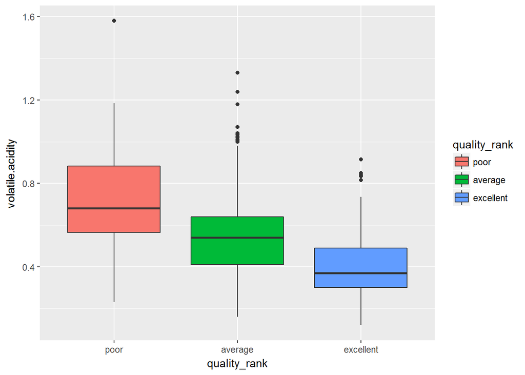

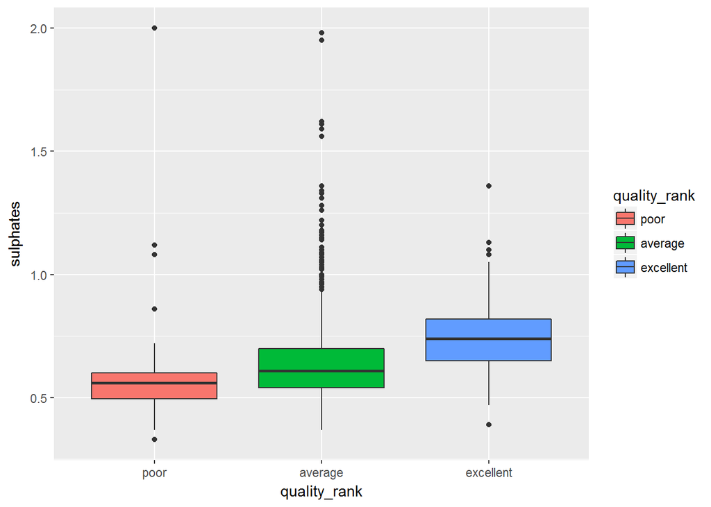

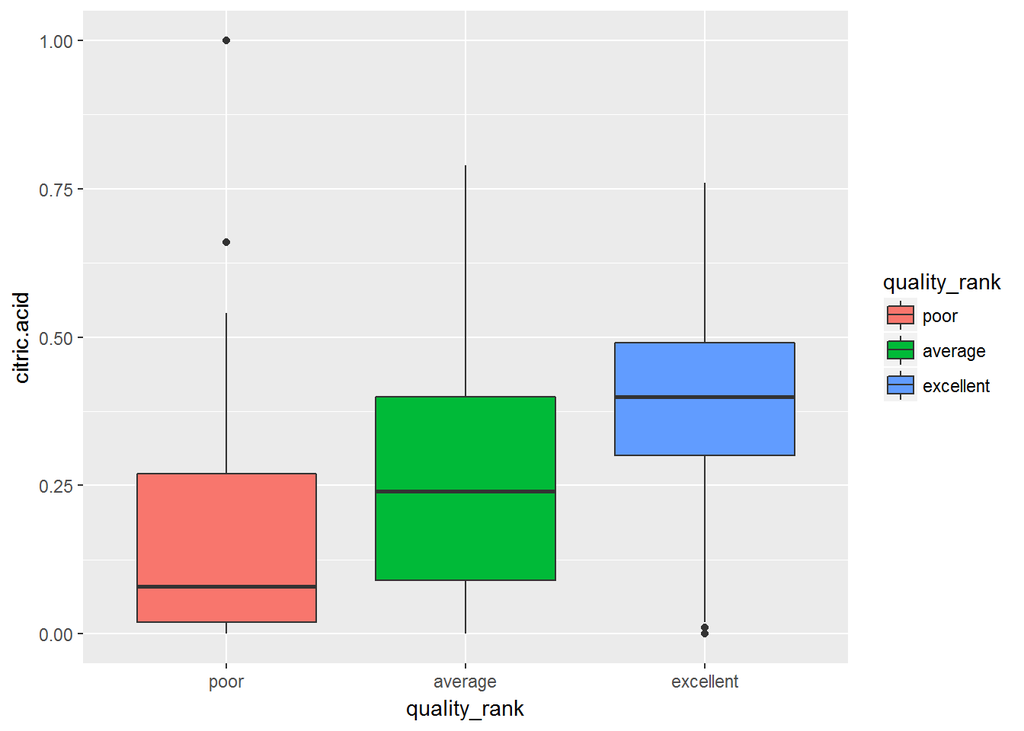

Violin for the quality to alcohol content is shown below.

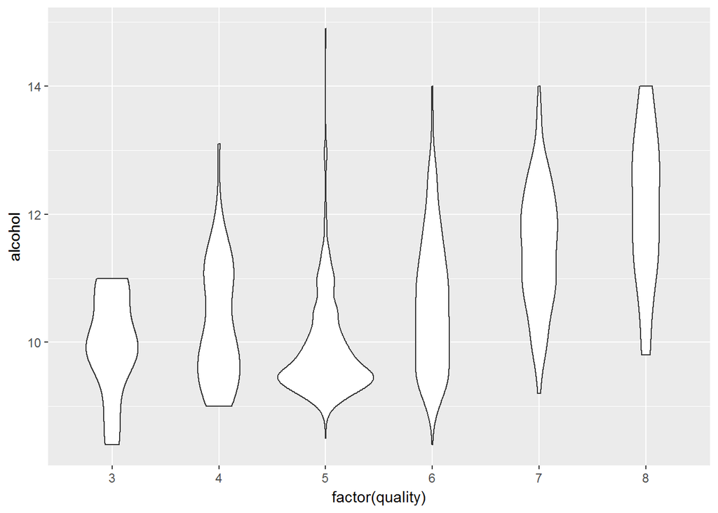

This violin plot shows the increasing trend of alcohol content affecting wine quality.

# Bivariate Analysis

In this analysis, we explore any relationships that may exist between the newly transformed quality_rank attribute with the chemical properties.

## Chemical Properties Distributions Analysis

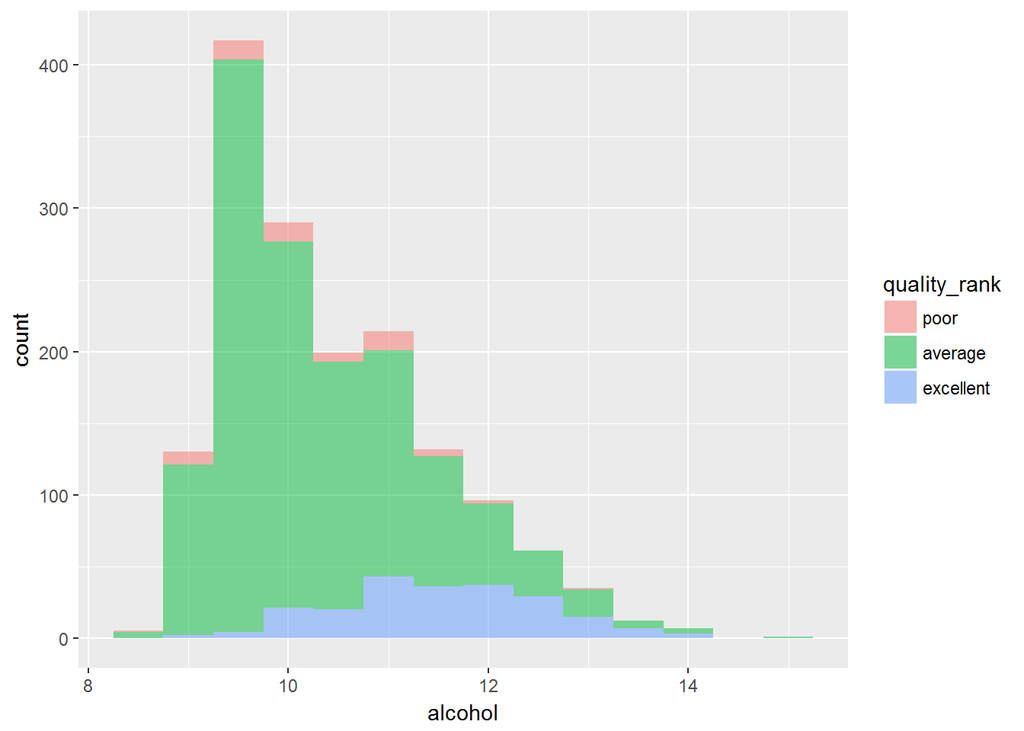

The plot shows the distribution of alcohol at the different wine quality ranks. The data distribution for each quality is not equal (ie there’s minimal observations for poor tasting wine) so it makes it difficult to visually denote disitrbutions from the histogram. A normalization of the plot is seen below.

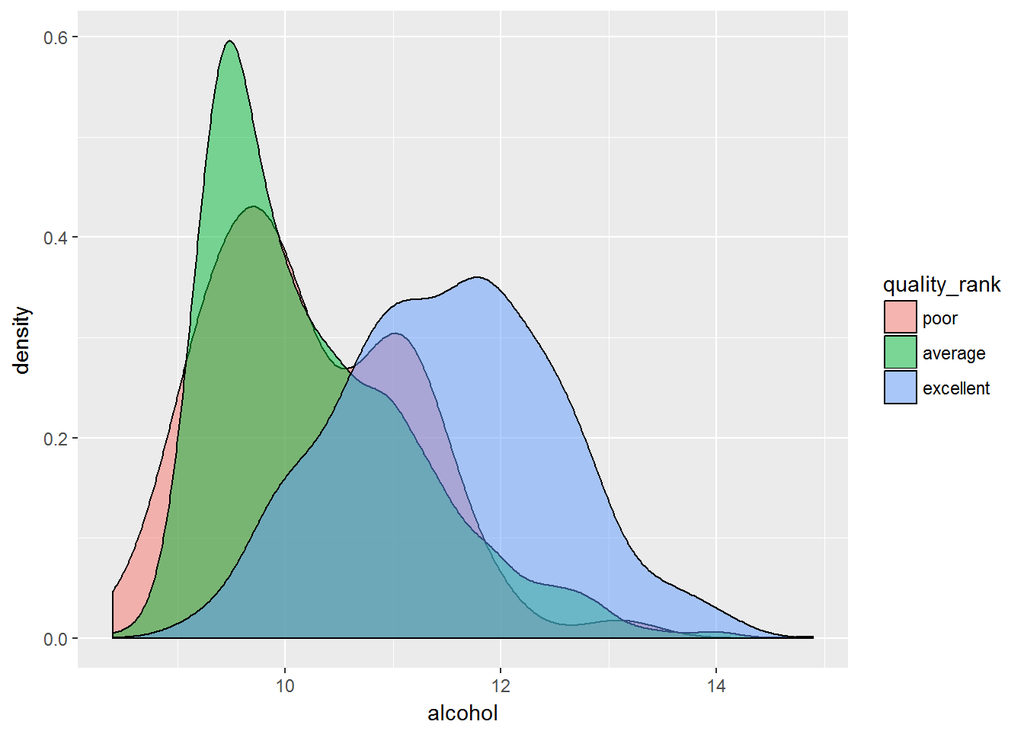

For the remaining 3 attributes of high correlation coefficients - volatile.acidity, sulphates, citric.acid - the distributions plots against the wine quality at the different ranks are below.

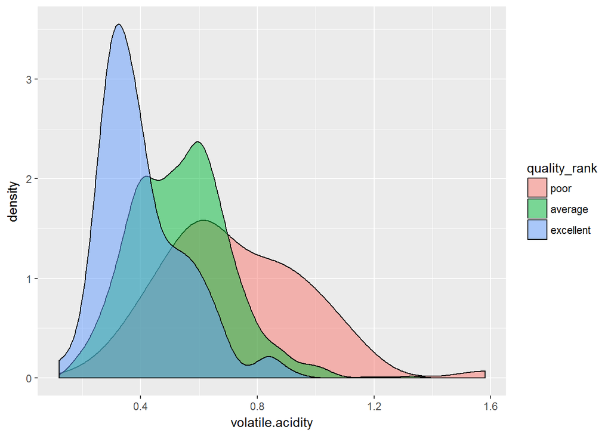

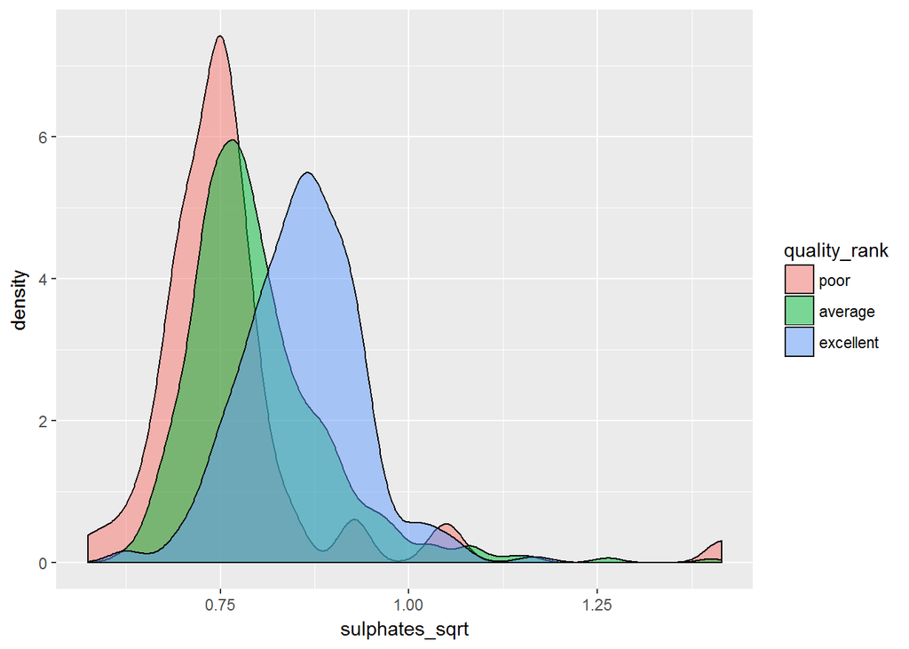

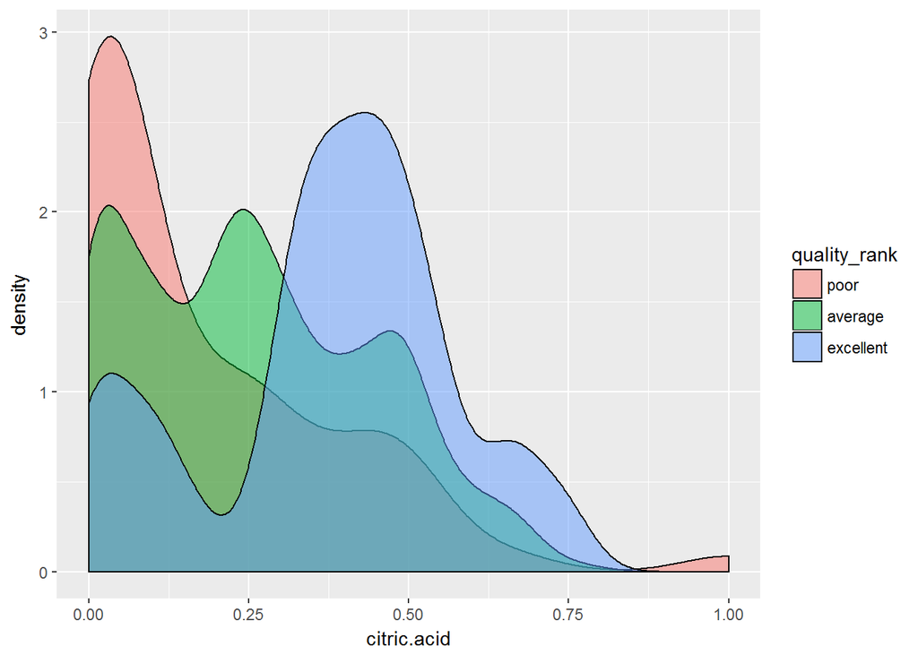

## Observation Summary of the Bivariate Plots

1. Alcohol has the strongest correlation to the quality of wine, with a coefficient = 0.476.
2. Fixed acidity has no effect on quality.
3. Volatile acidity has a negative correlation on quality.
4. pH has a negative effect on quality - meaning, the more acidic a wine is, the higher the quality.
5. Residual sugar has no effect on quality.
6. Density has a minor negative effect on quality.
7. Sulphates have a minor positive effect on quality.
8. Alcohol contributes to the quality of wine by a factor of 22%, the most out of any of the other variables in the wine data set.

# Multivariate Plots Section

## Effect of Acids on Wine Quality

Based on the bivariate investigation of the role acids play in the quality of wine we know that the more acidic a wine is, the higher the quality is. Let’s investigate how different combinations of acids can affect the quality.

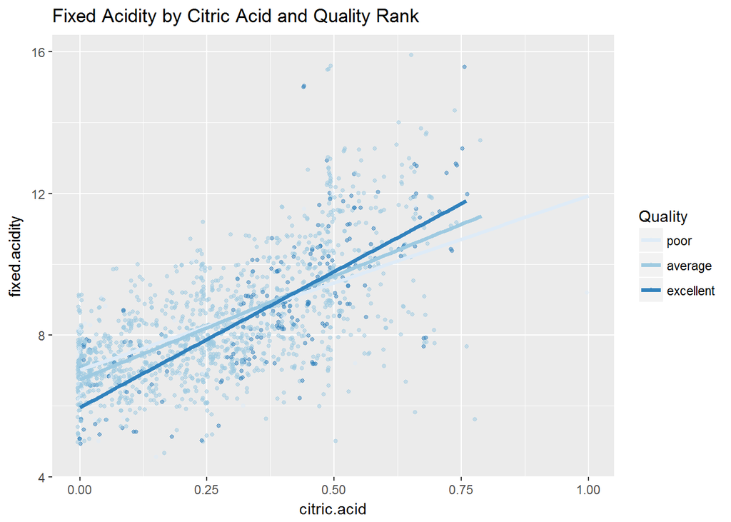

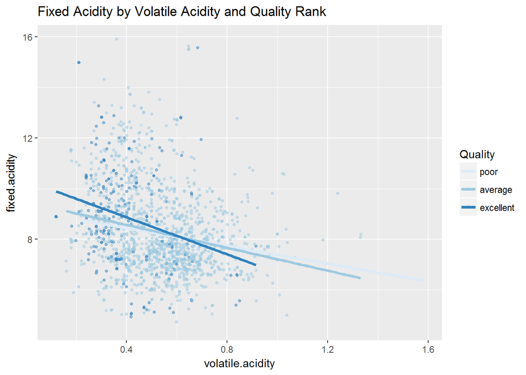

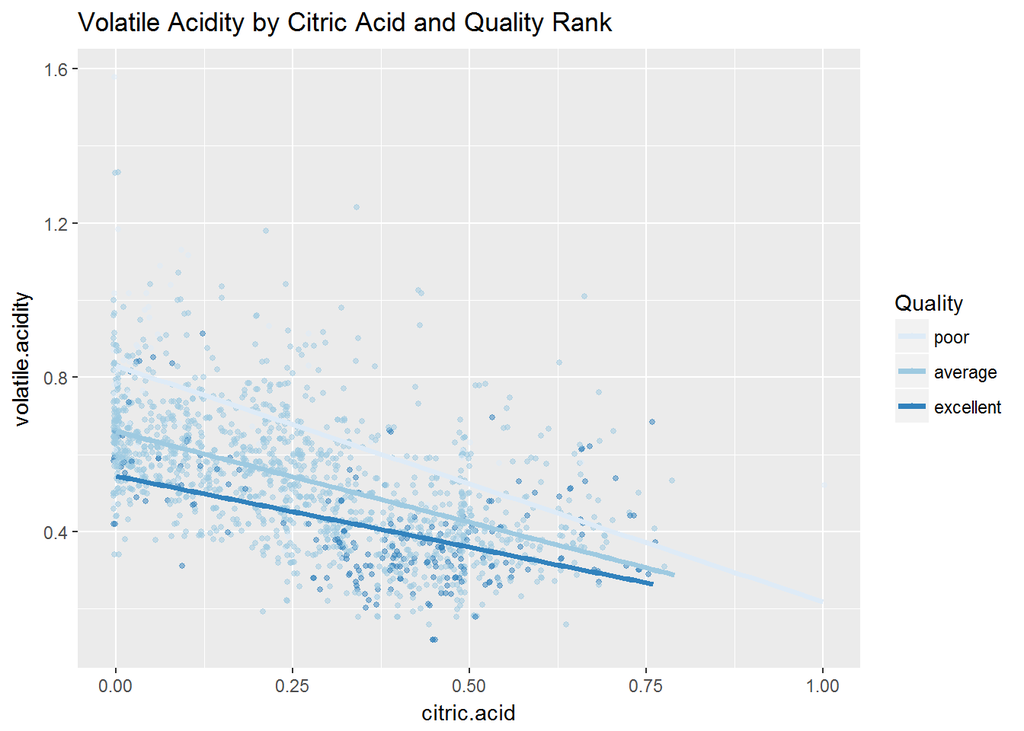

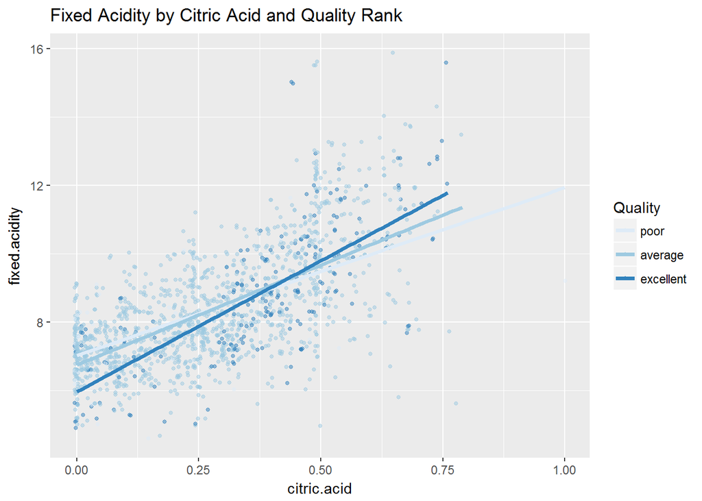

- Fixed Acidity by Citric Acid and Quality Rank - There doesn’t seem to be any correlation to the wine quality with these two variables.
- Fixed Acidity by Volatile Acidity and Quality Rank - There doesn’t seem to be any correlation to the wine quality with these two variables.
- Volatile Acidity by Citric Acid and Quality Rank - Lower amounts of volatile acidity and higher amounts of citric acid lead to better quality wine.
- Fixed Acidity by Citric Acid - There doesn’t seem to be any correlation to the wine quality with these two variables.